# Entrega 2 - Proyecto de Riesgo ANID

Andrea Araya - Pablo Bellei - Luis Cuello - Gino Benedetti - Gabriela Ossa

2021-07-09

En el proceso de evaluación de los proyectos se identifican falencias en la ejecución, es decir, hay proyectos que presentan dificultades para cumplir con las exigencias académicas mínimas para su adecuado cierre, tales como: la presentación de un o manuscrito académico aceptado, publicado o en prensa, el cumplimiento de las exigencias éticas a través de un informe de seguimiento ético y/o bioético, la realización de alguna actividad de divulgación científica, entre otras.

Por lo tanto, se vuelve necesario para la Subdirección diseñar un método que identifique patrones (variables) de no cumplimiento académico de los proyectos, y así poder crear un clasificador de riesgo, con la finalidad de alertar de forma temprana a los evaluadores, e implementar medidas de acompañamiento a los y las investigadoras para lograr el cumplimiento de las exigencias académicas y así, puedan finalizar exitosamente su investigación.

Las principales preguntas a responder serán: ¿Cuáles son los proyectos que están más propensos a presentar dificultades para culminar con éxito su investigación?, ¿Es posible asignar una clasificación de riesgo a los proyectos de acuerdo a ciertos patrones?, ¿Existen variables que ayuden a predecir el riesgo de no cumplimiento de un proyecto?

El modelo analítico construido a partir de la información disponible, podrá predecir el incumplimiento académico de los proyectos a partir de la clasificación de riesgo asociada a ciertas variables.

La información se encuentra almacenada en una base de datos administrada por la Subdirección de Proyectos de Investigación. Se cuenta con datos de los proyectos aprobados desde el año 1991 hasta la fecha, lo que se encuentran desagregados por proyecto de investigación, en los tres principales fondos de investigación individual: Regular, Postdoctorado e Iniciación en investigación.

Las variables se encuentran en una base de datos relacional y se necesita una revisión de esta para poder extraer muestras, transformarlas y poder analizarlas.

En la Subdirección de Proyectos de Investigación existe información respecto de los proyectos adjudicados, la cual se recolecta a través de los procesos de postulación, evaluación, adjudicación y seguimiento técnico. A partir de esta información histórica, se buscará identificar las variables que puedan incidir en el incumplimiento académico de un proyecto y de esta manera diseñar un modelo de clasificación de riesgo.

Esta información se tratará de manera anónima para resguardar la confidencialidad de los/as investigadores/as, para estos efectos se considera la transformación de las variables de identificación originales (RUT, folio) a una nueva variable de identificación para efectos de procesamiento de la información.

Para abordar este proyecto se utilizará el método CRISP-DM (Cross Industry Standard Process for Data Mining), que desglosa el proceso en seis fases: 1) comprensión del negocio, 2) comprensión de los datos, 3) preparación de los datos, 4) modelado, 5) evaluación de los resultados y 6) puesta en marcha. En las primeras etapas, los esfuerzos estarán puestos en conocer y comprender los mecanismos de control y seguimiento de los proyectos adjudicados, para lograr identificar las variables que pueden ser utilizadas para evaluar el riesgo de incumplimiento. Una vez identificadas las variables, se procederá a la preparación de los datos para su posterior análisis y modelación. Finalmente, se evaluarán los resultados respecto de los objetivos iniciales y la aplicación de la herramienta por parte de los profesionales de la Subdirección.

Los datos necesarios para desarrollar este proyecto serán obtenidos directamente desde la Subdirección. Estos se encuentran almacenados en una base de datos institucional y el periodo disponible es desde el año 1991 a la fecha. En este momento, se cuenta con la autorización para llevar a cabo esta iniciativa y utilizar los datos disponibles.

## Anexo

### Carta Gantt

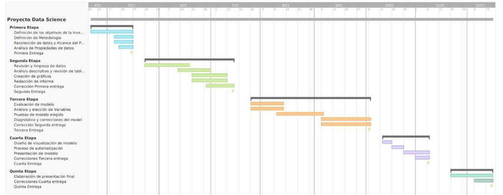

## 1. Comprensión del negocio

El ciclo de un proyecto que postula a los instrumentos de FONDECYT de la ANID se grafica en la siguiente imagen. Se inicia con el proceso de postulación, seguido por la evaluación y posterior adjudicación. Si un proyecto resulta adjudicado, entonces entra a un proceso de seguimiento, el cual se estructura por dos aspectos: el aspecto técnico y el aspecto financiero. En este trabajo nos acotaremos al seguimiento técnico.

[figure not shown]

Parte de la evaluación técnica incluye la elaboración y entrega de un informe académico, el cual es evaluado por la ANID, y a partir de su resultado se puede clasificar el proyecto como ‘aprobado’, ‘rechazado’ o ‘en proceso’. A continuación se presenta un flujo con los detalles respecto de la revisión y fallo de los aspectos comprometidos.

[figure not shown]

## 2. Comprensión de los datos

Los datos están estructurados en nueve tablas, todas disponibles en formato excel. A continuación, se identifica cada tabla, con la cantidad de variables y registros que contienen. Previamente, cada tabla fue innominada a requerimiento de la Institución. En total existen 55 variables únicas. La *primary key* de todas las tablas corresponde al código que identifica a cada proyecto, denominado `cod_folio`.

| Nombre tabla | Número de variables | Número de registros |
| --- | --- | --- |
| Data general | 25 | 14.850 |
| Etapa | 8 | 47.253 |
| Bioetica | 11 | 6.010 |
| Disciplinas | 13 | 4.093 |
| Miembros | 8 | 3.198 |
| Monto | 5 | 14.874 |
| Situacion especial | 13 | 4.221 |
| Cambios_a | 9 | 40.741 |
| Cambios_b | 8 | 40.083 |

Inicialmente trabajaremos con dos tablas, una que contiene los datos generales del proyecto denominada `data_gral` y otra llamada `etapa`, que incluye datos específicos sobre el avance del proyecto.

- La tabla `data_gral` incluye las siguientes variables: año proyecto, duración, fecha de término, tipo de concurso, disciplina, universidad, entre otras.
- La tabla `etapa` incluye las siguientes variables: fecha actualización del estado de etapa, el estado (aprobado, rechazado o en ejecución), entre otras.

En la siguiente figura se muestra un modelo relacional para los datos.

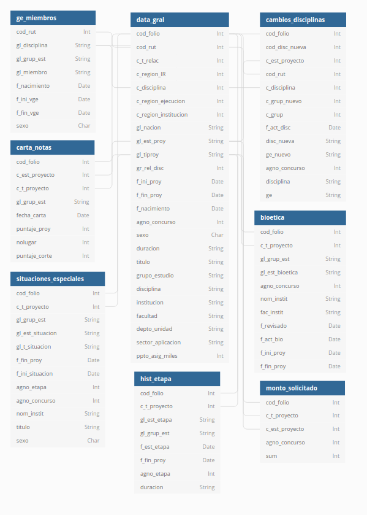

## 3. Preparación de los datos

### 3.1 Carga y limpieza de datos

Se utilizaron las siguientes funciones para la carga y limpieza de datos:

- Carga de datos : `readxl::read_excel`
- Visualización formato variables : `dplyr::glimpse`
- Visualización de datos faltantes : `naniar::vis_miss`

Los principales problemas detectados en la limpieza y su solución se presentan a continuación:

| Problema | Solucion |
| --- | --- |
| Variables caracter cargan como númerica | Se aplica función `as.character` |
| Nombres campos con espacios | Se aplica función `janitor::clean_names` |
| Entradas con datos faltantes | Se aplica `na.omit` |

### 3.1.1 Limpieza tabla Data General

A continuación se muestra el retorno de las funciones `dplyr::glimpse` y `naniar::vis_miss` aplicadas a la tabla `data_gral` depués de la limpieza.

```
## Rows: 14,850
## Columns: 25
## $ cod_folio            <chr> "1061", "1062", "1063", "1064", "1065", "1066", "~
## $ sexo                 <chr> "M", "M", "F", "F", "M", "M", "M", "M", "M", "M",~
## $ c_t_relac            <chr> "1", "1", "1", "1", "1", "1", "1", "1", "1", "1",~
## $ gl_nacion            <chr> "CHILE", "CHILE", "CHILE", "CHILE", "CHILE", "CHI~
## $ c_region_del_ir      <chr> NA, NA, "13", "12", "13", NA, "13", "13", "13", "~
## $ cod_rut              <chr> "1978", "1910", "1256", "3501", "1614", "1576", "~
## $ gl_est_proy          <chr> "APROBADO", "APROBADO", "APROBADO", "APROBADO", "~
## $ f_ini_proy           <dttm> 2006-03-15, 2006-03-15, 2006-03-15, 2006-03-15, ~
## $ f_fin_proy           <dttm> 2009-03-15, 2008-03-15, 2009-03-15, 2010-03-15, ~
## $ duracion             <dbl> 3, 2, 3, 4, 3, 3, 4, 3, 3, 3, 3, 4, 4, 4, 3, 3, 4~
## $ gl_tiproy            <chr> "REGULAR", "REGULAR", "REGULAR", "REGULAR", "REGU~
## $ agno_concurso        <dbl> 2006, 2006, 2006, 2006, 2006, 2006, 2006, 2006, 2~
## $ titulo               <chr> "ESTUDIO DE LA RESPUESTA A EMBUTICION DE ACEROS D~
## $ grupo_estudoop       <chr> "INGENIERIA 1", "CS. ECONOM/ADMI", "SOCIOLOGIA CS~
## $ disciplina           <chr> "INGENIERIA DE MATERIALES", "FINANZAS", "CAMBIO S~
## $ gr_rel_disc          <chr> "1", "1", "1", "1", "1", "1", "1", "1", "1", "1",~
## $ c_disciplina         <chr> "86", "217", "164", "159", "43", "93", "36", "36"~
## $ sector_aplicacion    <chr> "TECNICAS DE MANUFACTURAS Y DE PROCESOS.", "CONOC~
## $ c_region_ejecucion   <chr> "13", "13", "13", "12", "13", "13", "13", "13", "~
## $ institucion          <chr> "UNIV.DE SANTIAGO DE CHILE", "UNIV.ADOLFO IBANEZ"~
## $ facultad             <chr> "FAC.DE INGENIERIA", "ESCUELA DE NEGOCIOS-SANTIAG~
## $ depto_unidad         <chr> "DEPTO.ING. METALURGICA", "ESCUELA DE NEGOCIOS-SA~
## $ c_region_institucion <chr> "13", "13", "13", "12", "13", "13", "13", "13", "~
## $ f_nacimiento         <dttm> 1960-02-01, 1972-09-08, 1946-11-26, 1972-09-08, ~
## $ miles_de_ppto_asig   <dbl> 32543, 16802, 28100, 124425, 116028, 45715, 84791~
```

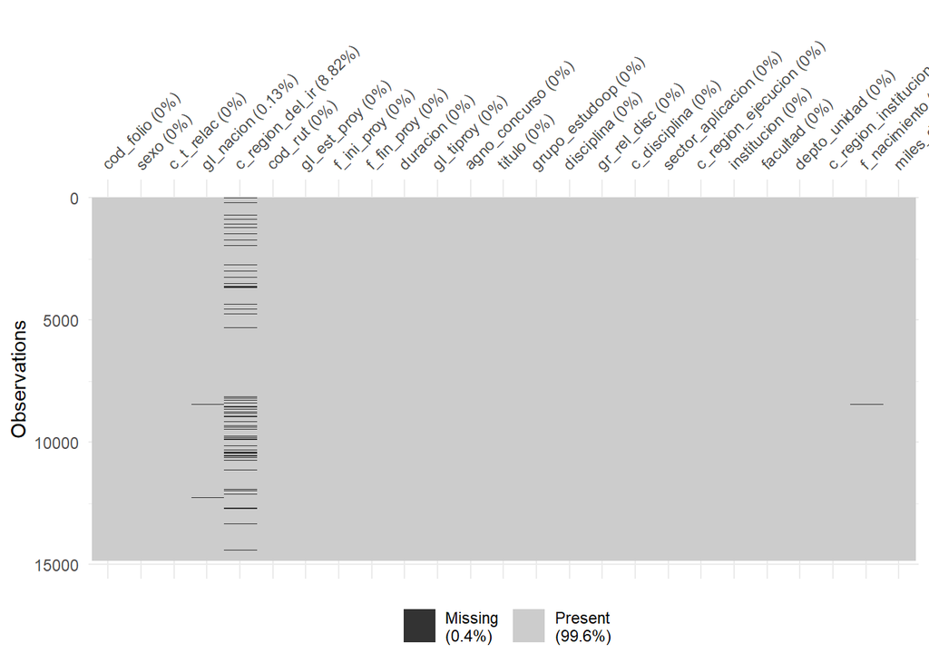

Notar los siguientes aspectos relevantes: a) que en total se identificaron 14.850 proyectos para el periodo 2006-2021, b) que pueden ser clasificados por tipo de proyecto `gl_tiproy` (iniciación, postdoctorado y regular), y c) que la duración de cada uno puede variar entre uno y cuatros años, los cuales denominaremos etapas. [^1]

### 3.1.1 Limpieza tabla Etapa

Además, fue necesario reclasificar las categorías que toma la variable `gl_est_etapa`, dado que tiene 24 categorías y estas no son informativas por si mismas. De este modo, la nueva variable `etapas_agrupadas` solo toma tres valores `APROBADO`, `RECHAZADO` o `EN PROCESO`. Se entenderá por:

- `APROBADO`: cumple con las exigencias académicas establecidas en conformidad a las bases del concurso.
- `RECHAZADO`: no cumple con las exigencias académicas establecidas en conformidad a las bases del concurso, por lo tanto, se exigen rectificaciones que puedan cambiar esta situación.
- `EN PROCESO`: aquellos proyectos vigentes que se encuentran en ejecución, cuyo informe académico se encuentra recibido o en evaluación.

Por último, se añade una columna tiempo que equivale a la diferencia de tiempo límite inicial del proyecto menos el tiempo que tomó el proyecto en terminar.

A continuación se muestra el retorno de las funciones `dplyr::glimpse` y `naniar::vis_miss` aplicadas a la tabla `etapa` después de la limpieza.

```
## Rows: 25,016
## Columns: 10
## $ cod_folio        <chr> "1061", "1061", "1061", "1062", "1062", "1063", "1063~
## $ agno_etapa       <dbl> 2006, 2007, 2008, 2006, 2007, 2006, 2007, 2008, 2006,~
## $ c_t_proyecto     <chr> "1", "1", "1", "1", "1", "1", "1", "1", "1", "1", "1"~
## $ gl_est_etapa     <chr> "APROBADA", "APROBADA", "APROBADA", "APROBADA", "APRO~
## $ f_est_etapa      <dttm> 2007-05-07, 2008-04-11, 2009-04-14, 2007-05-07, 2012~
## $ duracion         <dbl> 3, 3, 3, 2, 2, 3, 3, 3, 4, 4, 4, 4, 3, 3, 3, 3, 3, 3,~
## $ f_fin_proy       <dttm> 2009-03-15, 2009-03-15, 2009-03-15, 2008-03-15, 2008~
## $ gl_grup_est      <chr> "INGENIERIA 1", "INGENIERIA 1", "INGENIERIA 1", "CS. ~
## $ tiempo           <drtn> 678 days, 338 days, -30 days, 313 days, -1453 days, ~
## $ etapas_agrupadas <chr> "APROBADO", "APROBADO", "APROBADO", "APROBADO", "APRO~
```

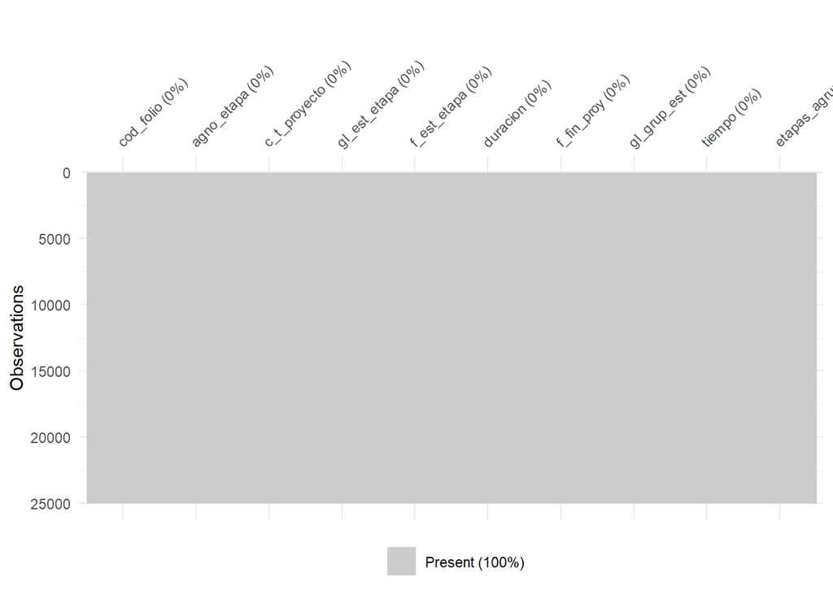

Luego de la limpieza, la tabla `etapa` está lista para ser usada más adelante.

### 4. Análsis Exploratorio

Primero, se grafican las variables de la tabla `data_gral` que se creen importantes, con la finalidad de ver cómo se relacionan entre sí. Estas son el número total de proyectos por año, desagregados por tipo de proyecto y duración.

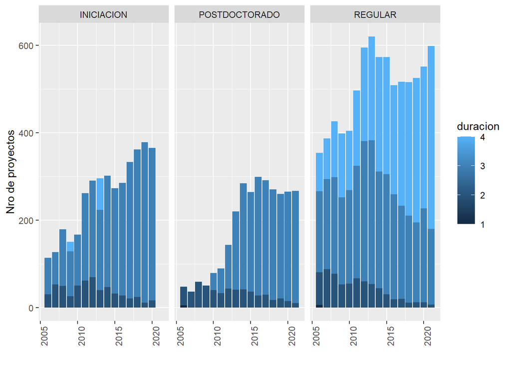

Luego, mirando sólo la tabla `etapa`, se quiere conocer la frecuencia según la clasificación estado de proyecto. Esto es:

| Var1 | Freq |
| --- | --- |
| APROBADO | 10189 |
| EN PROCESO | 173 |
| RECHAZADO | 642 |

En este punto, se ha extraído información relevante sobre ambas tablas por separado, pero ha llegado el momento de unirlas y responder preguntas más interesantes. Entonces, se crea una nueva tabla llamada `etapas_gral`, que es el resultado de un *inner_join* entre `data_gral`y `etapa`.

*Verificar de supuestos:*

1. Los proyectos en la categoría de rechazado se exceden en la duración oficial del proyecto.

Para verificar el supuesto, se realizó una grafica del delta de tiempo desde el término de la última etapa del proyecto versus la fecha de termino del proyecto. Tiempo estimado en días. Además, se muestran los principales estadísticos de resumen.

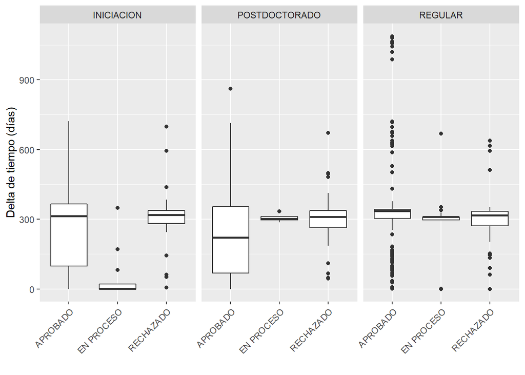

| gl_tiproy | etapas_agrupadas | mean_tiempo | max_tiempo | std_tiempo |
| --- | --- | --- | --- | --- |
| INICIACION | APROBADO | 304.67568 | 722 | 225.61522 |
| INICIACION | EN PROCESO | 46.07143 | 349 | 99.53157 |
| INICIACION | RECHAZADO | 310.07692 | 699 | 151.36893 |
| POSTDOCTORADO | APROBADO | 266.60684 | 861 | 220.01477 |
| POSTDOCTORADO | EN PROCESO | 306.50000 | 334 | 19.77372 |
| POSTDOCTORADO | RECHAZADO | 294.82857 | 671 | 138.42124 |
| REGULAR | APROBADO | 341.77620 | 1087 | 169.83027 |
| REGULAR | EN PROCESO | 286.83784 | 669 | 117.39878 |
| REGULAR | RECHAZADO | 305.00000 | 638 | 125.81345 |

Este supuesto no muestra una clara relación entre exceso en el tiempo de fin de proyecto, dado que muchos proyectos aprobados exceden por mucho la fecha límite.

2. Las macrozona de Chile influye en la posibilidad de caer en incumplimiento.

```
##
##              norte centro centro-sur  sur
##   APROBADO     322   7393       1378 1096
##   EN PROCESO     6    126         23   18
##   RECHAZADO     20    453        100   69
```

¿Será una función del tiempo?

```
##
##        APROBADO EN PROCESO RECHAZADO
##   2006      0.3        0.0       0.0
##   2007      1.3        0.0       0.0
##   2008      3.9        0.0       0.1
##   2009      4.9        0.0       0.1
##   2010      5.1        0.0       0.1
##   2011      5.1        0.0       0.2
##   2012      6.2        0.0       0.1
##   2013      7.3        0.0       0.1
##   2014      8.5        0.0       0.2
##   2015      9.1        0.0       0.5
##   2016      9.9        0.0       0.6
##   2017      8.9        0.0       0.9
##   2018      8.8        0.1       1.0
##   2019      7.3        0.5       1.0
##   2020      6.0        0.9       0.8
```

[^1]: Recordar que la tabla etapa actualiza el estado del proyecto anualmente